# Identification of a DNA methylation signature in blood cells from persons with Down Syndrome

## ABSTRACT (COSTRUISCI INTRODUZIONE BREVE)

Down Syndrome (DS) is characterized by a wide spectrum of clinical signs, which include segmental premature aging of central nervous and immune systems. Although it is well established that the causative defect of DS is the trisomy of chromosome 21, the molecular bases of its phenotype are still largely unknown. We used the Infinium HumanMethylation450 BeadChip to investigate DNA methylation patterns in whole blood from 29 DS persons, using their relatives (mothers and unaffected siblings) as controls. This family-based model allowed us to monitor possible confounding effects on DNA methylation patterns deriving from genetic and environmental factors. Although differentially methylated regions (DMRs) displayed a genome-wide distribution, they were enriched on chromosome 21. DMRs mapped in genes involved in developmental functions, including embryonic development (HOXA family) and haematological (RUNX1 and EBF4) and neuronal (NCAM1) development. Moreover, genes involved in the regulation of chromatin structure (PRMD8, KDM2B, TET1) showed altered methylation. The data also showed that several pathways are affected in DS, including PI3K-Akt signaling. In conclusion, we identified an epigenetic signature of DS that sustains a link between developmental defects and disease phenotype, including segmental premature aging.

STUDENT **2**

STEP 3 -> address = 10633381  
STEP 5 -> detPvalue threshold = 0.05  
STEP 7 -> normalization = preprocessNoob  
STEP 11 -> test = Anova correcting for female (vedi rob polverelli)

## STEPS OF THE ANALYSIS PIPELINE

### 1. Load raw data with minfi and create an object called RGset storing the RGChannelSet object (see Script Lesson3_bis_2019)

```r
rm(list=ls())

library(minfi)
library(knitr)
library(kableExtra)
library(gap)
```

```r
load("/home/pelmo/R_wd/Illumina450Manifest_clean.RData")
```

```r
targets <- read.metharray.sheet("/home/pelmo/drd_project/data/")
```

```
[read.metharray.sheet] Found the following CSV files:
```

```
[1] "/home/pelmo/drd_project/data//Input_data/Samplesheet_report.csv"
```

```r
RGset <- read.metharray.exp(targets=targets)
```

```r
kable(targets) %>% kable_styling("bordered")
```

| Sample_Name | Group | Female | Age | Slide | Array | Basename |
| --- | --- | --- | --- | --- | --- | --- |
| 1001 | DS | 0 | 18 | 5775278008 | R01C01 | /home/pelmo/drd_project/data//Input_data/5775278008_R01C01 |
| 3001 | WT | 0 | 21 | 5775278008 | R02C01 | /home/pelmo/drd_project/data//Input_data/5775278008_R02C01 |
| 1003 | DS | 1 | 12 | 5775278008 | R04C01 | /home/pelmo/drd_project/data//Input_data/5775278008_R04C01 |
| 3003 | WT | 1 | 22 | 5775278008 | R05C01 | /home/pelmo/drd_project/data//Input_data/5775278008_R05C01 |
| 1009 | DS | 0 | 24 | 5775278035 | R01C01 | /home/pelmo/drd_project/data//Input_data/5775278035_R01C01 |
| 3009 | WT | 1 | 21 | 5775278035 | R02C01 | /home/pelmo/drd_project/data//Input_data/5775278035_R02C01 |
| 1010 | DS | 0 | 33 | 5775278035 | R04C01 | /home/pelmo/drd_project/data//Input_data/5775278035_R04C01 |
| 3010 | WT | 1 | 41 | 5775278035 | R05C01 | /home/pelmo/drd_project/data//Input_data/5775278035_R05C01 |

```r
RGset
```

```
class: RGChannelSet
dim: 622399 8
metadata(0):
assays(2): Green Red
rownames(622399): 10600313 10600322 ... 74810490 74810492
rowData names(0):
colnames(8): 5775278008_R01C01 5775278008_R02C01 ... 5775278035_R04C01 5775278035_R05C01
colData names(8): Sample_Name Group ... Basename filenames
Annotation
  array: IlluminaHumanMethylation450k
  annotation: ilmn12.hg19
```

### 2. Create the dataframes Red and Green to store the red and green fluorescence respectively

```r
Red <- data.frame(getRed(RGset))
Green <- data.frame(getGreen(RGset))
```

```r
kable(head(Red)) %>% kable_styling("bordered") %>% scroll_box(width = "100%")
```

|  | X5775278008_R01C01 | X5775278008_R02C01 | X5775278008_R04C01 | X5775278008_R05C01 | X5775278035_R01C01 | X5775278035_R02C01 | X5775278035_R04C01 | X5775278035_R05C01 |
| --- | --- | --- | --- | --- | --- | --- | --- | --- |
| 10600313 | 741 | 964 | 1310 | 1080 | 481 | 792 | 1347 | 1747 |
| 10600322 | 2150 | 3120 | 3412 | 3187 | 1451 | 1945 | 4129 | 4160 |
| 10600328 | 1872 | 2049 | 2680 | 2135 | 1288 | 1338 | 2936 | 3131 |
| 10600336 | 17484 | 20501 | 23434 | 22802 | 7554 | 10562 | 24026 | 24757 |
| 10600345 | 3234 | 4035 | 5776 | 4836 | 2054 | 2950 | 6901 | 5282 |
| 10600353 | 1133 | 1481 | 2197 | 1809 | 818 | 1045 | 2105 | 2520 |

```r
kable(head(Green)) %>% kable_styling("bordered") %>% scroll_box(width = "100%")
```

|  | X5775278008_R01C01 | X5775278008_R02C01 | X5775278008_R04C01 | X5775278008_R05C01 | X5775278035_R01C01 | X5775278035_R02C01 | X5775278035_R04C01 | X5775278035_R05C01 |
| --- | --- | --- | --- | --- | --- | --- | --- | --- |
| 10600313 | 489 | 499 | 740 | 736 | 259 | 373 | 680 | 840 |
| 10600322 | 9008 | 9265 | 12566 | 11514 | 4080 | 5289 | 11555 | 11367 |
| 10600328 | 2558 | 2940 | 3306 | 3149 | 1221 | 1558 | 3280 | 3000 |
| 10600336 | 2119 | 2483 | 3582 | 3246 | 1104 | 1374 | 3929 | 2588 |
| 10600345 | 4295 | 4618 | 6039 | 5406 | 1729 | 2622 | 4709 | 5824 |
| 10600353 | 4732 | 6038 | 7091 | 6956 | 2126 | 2667 | 5390 | 5766 |

```r
dim(Red)
```

```
[1] 622399      8
```

```r
dim(Green)
```

```
[1] 622399      8
```

### 3. 3. Fill the following table: what are the Red and Green fluorescence for the address assigned to you? (suggestion: subset the Red and Green dataframes by setting rownames==”the Address you want”). Optional: check from the manifest file if the address corresponds to a Type I or a Type II probe and, in case of Type I probe, report its color.

```r
my_address <- "10633381"
```

##qua sotto uso [aaaa,] senza niente dopo virgola perche sto selezionando [rows,columns] e lasciando vuoto scelgo tutte le columns

```r
Illumina450Manifest_clean_pelmo[Illumina450Manifest_clean_pelmo$AddressA_ID==my_address,]$Infinium_Design_Type
```

```
factor(0)
Levels: I II
```

The output of the above command returns a null factor; this means that my address doesn’t correspond to a probe A.

```r
Illumina450Manifest_clean_pelmo[Illumina450Manifest_clean_pelmo$AddressB_ID==my_address,]$Infinium_Design_Type
```

```
[1] I
Levels: I II
```

Therefore, my address corresponds to a probe B of type I.

```r
Illumina450Manifest_clean_pelmo[Illumina450Manifest_clean_pelmo$AddressB_ID==my_address,]$Color_Channel
```

```
[1] Red
Levels:  Grn Red
```

The color of my type I probe is red.

#Just in case I will need it, I obtain the illumina ID corresponding to the CpG locus

```r
#my_address_id <- Illumina450Manifest_clean_pelmo[Illumina450Manifest_clean_pelmo$AddressB_ID==my_address,]$IlmnID
#my_address_id
```

```r
my_address_red <- t(Red[rownames(Red) %in% my_address,])


my_address_green <- t(Green[rownames(Green) %in% my_address,])

my_address_green
```

```
                   10633381
X5775278008_R01C01      521
X5775278008_R02C01      703
X5775278008_R04C01      927
X5775278008_R05C01      886
X5775278035_R01C01      286
X5775278035_R02C01      394
X5775278035_R04C01      878
X5775278035_R05C01     1098
```

```r
my_address_red
```

```
                   10633381
X5775278008_R01C01     1690
X5775278008_R02C01     2152
X5775278008_R04C01     2596
X5775278008_R05C01     2397
X5775278035_R01C01     1023
X5775278035_R02C01     1368
X5775278035_R04C01     3387
X5775278035_R05C01     2963
```

```r
my_address_fluorescences <- merge(my_address_red, my_address_green, by=0)
colnames(my_address_fluorescences) <- c("Sample", "Red fluor", "Green fluor")
kable(my_address_fluorescences) %>% kable_styling("bordered", full_width = F)
```

| Sample | Red fluor | Green fluor |
| --- | --- | --- |
| X5775278008_R01C01 | 1690 | 521 |
| X5775278008_R02C01 | 2152 | 703 |
| X5775278008_R04C01 | 2596 | 927 |
| X5775278008_R05C01 | 2397 | 886 |
| X5775278035_R01C01 | 1023 | 286 |
| X5775278035_R02C01 | 1368 | 394 |
| X5775278035_R04C01 | 3387 | 878 |
| X5775278035_R05C01 | 2963 | 1098 |

#a <- getProbeInfo(RGset) #altro metodo per fare step 3 capire colore e tipo probe

### 4. Create the object MSet.raw

```r
MSet.raw <- preprocessRaw(RGset)
```

```r
kable(head(getMeth(MSet.raw))) %>% kable_styling("bordered") %>% scroll_box(width="100%")
```

|  | 5775278008_R01C01 | 5775278008_R02C01 | 5775278008_R04C01 | 5775278008_R05C01 | 5775278035_R01C01 | 5775278035_R02C01 | 5775278035_R04C01 | 5775278035_R05C01 |
| --- | --- | --- | --- | --- | --- | --- | --- | --- |
| cg00050873 | 9501 | 11858 | 1025 | 990 | 4737 | 514 | 16028 | 1377 |
| cg00212031 | 663 | 1253 | 924 | 855 | 377 | 448 | 3538 | 1265 |
| cg00213748 | 2010 | 2651 | 1013 | 907 | 1382 | 428 | 4420 | 1271 |
| cg00214611 | 474 | 633 | 941 | 869 | 371 | 558 | 1138 | 1281 |
| cg00455876 | 3814 | 5653 | 887 | 875 | 2233 | 485 | 7367 | 1277 |
| cg01707559 | 736 | 765 | 1321 | 969 | 431 | 509 | 3867 | 1458 |

### 5. Perform the following quality checks and provide a brief comment to each step:

• QCplot

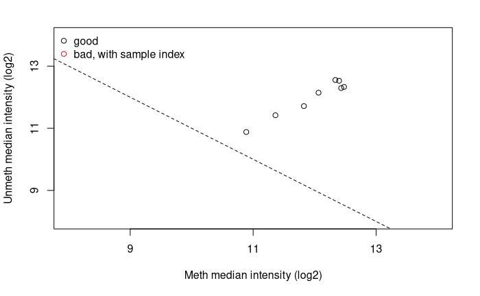

```r
qc <- getQC(MSet.raw)
plotQC(qc)
```

As can be seen in the QC plot, all the samples appear to be of acceptable quality, with no sample below the cutoff line.

• Check the intensity of negative controls using minfi

```r
control_probes <- data.frame(getProbeInfo(RGset, type= "Control"))

control_probes_type <- table(control_probes$Type)
control_probes_type <- as.data.frame(control_probes_type)
colnames(control_probes_type) <- c("Control type", "Freq")
control_probes_type <- control_probes_type[order(-control_probes_type["Freq"]),]
rownames(control_probes_type) <- NULL

kable(control_probes_type) %>% kable_styling("bordered", full_width = F)%>% scroll_box(height = "250px")
```

| Control type | Freq |
| --- | --- |
| NEGATIVE | 613 |
| NORM_C | 61 |
| NORM_T | 61 |
| NORM_A | 32 |
| NORM_G | 32 |
| BISULFITE CONVERSION I | 12 |
| SPECIFICITY I | 12 |
| BISULFITE CONVERSION II | 4 |
| EXTENSION | 4 |
| NON-POLYMORPHIC | 4 |
| STAINING | 4 |
| HYBRIDIZATION | 3 |
| SPECIFICITY II | 3 |
| TARGET REMOVAL | 2 |
| RESTORATION | 1 |

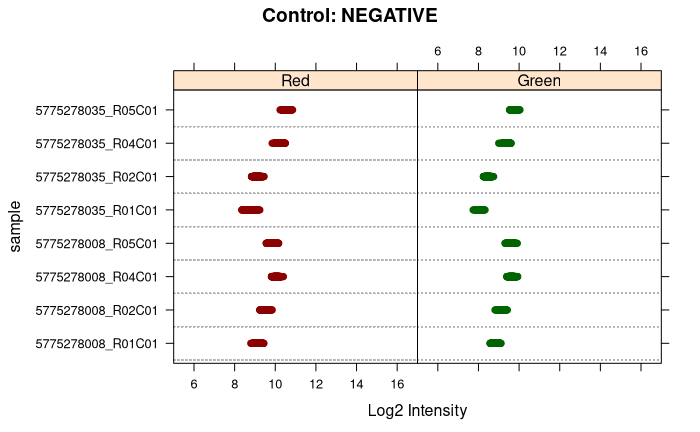

```r
controlStripPlot(RGset, controls="NEGATIVE")
```

The log2 intensities of the negative controls are within the detection range for all of the samples

• Calculate detection pValues; for each sample, how many probes have a detection p-value higher than the threshold assigned to each student?

```r
pval_threshold <- 0.05
detp_value <- detectionP(RGset)
```

```r
failed <- (detp_value > pval_threshold)
failed_df <- t(data.frame(apply(failed,2,table)))
samples_df <- rownames(failed_df)
rownames(failed_df) <- NULL
failed_df <- cbind(samples_df, failed_df)
colnames(failed_df) <- c("Samples", "pValue < 0.05", "pValue > 0.05")
kable(failed_df) %>% kable_styling("bordered", full_width = F)
```

| Samples | pValue < 0.05 | pValue > 0.05 |
| --- | --- | --- |
| X5775278008_R01C01 | 485100 | 412 |
| X5775278008_R02C01 | 485154 | 358 |
| X5775278008_R04C01 | 484779 | 733 |
| X5775278008_R05C01 | 484735 | 777 |
| X5775278035_R01C01 | 485151 | 361 |
| X5775278035_R02C01 | 484916 | 596 |
| X5775278035_R04C01 | 485243 | 269 |
| X5775278035_R05C01 | 484609 | 903 |

```r
failed_overall <- rowMeans(failed)
which_failed <- (failed_overall>0.01)
length(which_failed)
```

```
[1] 485512
```

```r
bad_probes <- names(which_failed[which_failed==TRUE])
head(bad_probes)
```

```
[1] "cg00050873" "cg00212031" "cg00213748" "cg00214611" "cg00455876" "cg01707559"
```

```r
length(bad_probes)
```

```
[1] 1905
```

### 6. Calculate raw beta and M values and plot the densities of mean methylation values, dividing the samples in DS and WT (suggestion: subset the beta and M values matrixes in order to retain DS or WT subjects and apply the function mean to the 2 subsets).

```r
beta <- getBeta(MSet.raw)
m <- getM(MSet.raw)
```

```r
kable(targets) %>% kable_styling("bordered")
```

| Sample_Name | Group | Female | Age | Slide | Array | Basename |
| --- | --- | --- | --- | --- | --- | --- |
| 1001 | DS | 0 | 18 | 5775278008 | R01C01 | /home/pelmo/drd_project/data//Input_data/5775278008_R01C01 |
| 3001 | WT | 0 | 21 | 5775278008 | R02C01 | /home/pelmo/drd_project/data//Input_data/5775278008_R02C01 |
| 1003 | DS | 1 | 12 | 5775278008 | R04C01 | /home/pelmo/drd_project/data//Input_data/5775278008_R04C01 |
| 3003 | WT | 1 | 22 | 5775278008 | R05C01 | /home/pelmo/drd_project/data//Input_data/5775278008_R05C01 |
| 1009 | DS | 0 | 24 | 5775278035 | R01C01 | /home/pelmo/drd_project/data//Input_data/5775278035_R01C01 |
| 3009 | WT | 1 | 21 | 5775278035 | R02C01 | /home/pelmo/drd_project/data//Input_data/5775278035_R02C01 |
| 1010 | DS | 0 | 33 | 5775278035 | R04C01 | /home/pelmo/drd_project/data//Input_data/5775278035_R04C01 |
| 3010 | WT | 1 | 41 | 5775278035 | R05C01 | /home/pelmo/drd_project/data//Input_data/5775278035_R05C01 |

```r
wt_samples <- targets[targets$Group=="WT",]
wt_samples
```

|  | Sample_Name | Group | Female | Age | Slide | Array | Basename |
| --- | --- | --- | --- | --- | --- | --- | --- |
| 2 | 3001 | WT | 0 | 21 | 5775278008 | R02C01 | /home/pelmo/drd_project/data//Input_data/5775278008_R02C01 |
| 4 | 3003 | WT | 1 | 22 | 5775278008 | R05C01 | /home/pelmo/drd_project/data//Input_data/5775278008_R05C01 |
| 6 | 3009 | WT | 1 | 21 | 5775278035 | R02C01 | /home/pelmo/drd_project/data//Input_data/5775278035_R02C01 |
| 8 | 3010 | WT | 1 | 41 | 5775278035 | R05C01 | /home/pelmo/drd_project/data//Input_data/5775278035_R05C01 |

```r
wt_samples_names <- sub("/home/pelmo/drd_project/data//Input_data/", "", wt_samples$Basename)
wt_samples_names
```

```
[1] "5775278008_R02C01" "5775278008_R05C01" "5775278035_R02C01" "5775278035_R05C01"
```

```r
ds_samples <- targets[targets$Group=="DS",]
#ds_samples
ds_samples_names <- sub("/home/pelmo/drd_project/data//Input_data/", "", ds_samples$Basename)
ds_samples_names
```

```
[1] "5775278008_R01C01" "5775278008_R04C01" "5775278035_R01C01" "5775278035_R04C01"
```

```r
samples_names <- colnames(RGset)
wt_beta <- beta[,samples_names %in% wt_samples_names]
wt_m <- m[,samples_names %in% wt_samples_names]
ds_beta <- beta[,samples_names %in% ds_samples_names]
ds_m <- m[,samples_names %in% ds_samples_names]

#head(wt_m)
#head(ds_m)
#head(wt_beta)
#head(ds_beta)
```

```r
mean_wt_beta <- apply(wt_beta,1, mean)
mean_ds_beta <- apply(ds_beta,1, mean)
mean_wt_m <- apply(wt_m,1, mean)
mean_ds_m <- apply(ds_m,1, mean)
```

```r
plot(density(mean_wt_beta, na.rm=T), main="Density of mean Beta values", col="blue",xlab="Beta", ylab="Density")
lines(density(mean_ds_beta,na.rm=T), col="red")
```

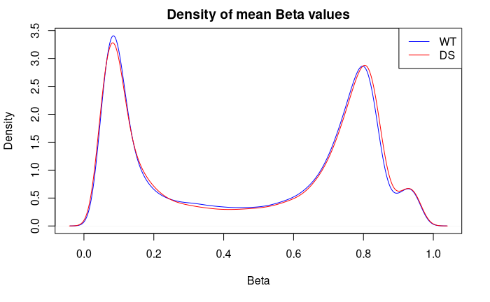

```r
legend("topright", legend=c("WT", "DS"), col=c("blue", "red"), lty=1:1)
```

```r
plot(density(mean_wt_m, na.rm=T), main="Density of mean M values", col="blue",xlab="Beta", ylab="Density")
legend("topright", legend=c("WT", "DS"), col=c("blue", "red"), lty=1:1)
```

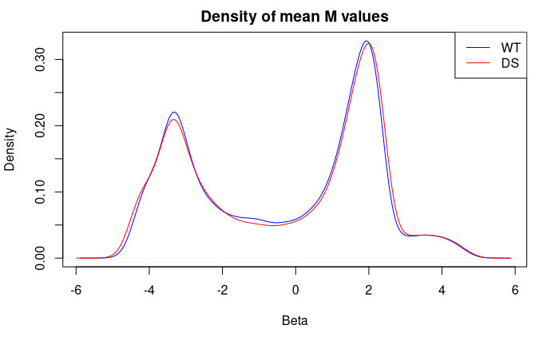

```r
lines(density(mean_ds_m, na.rm=T), col="red")
```

```r
NA
NA
```

### 7. Compare raw data with normalized data using the function assigned to each student (see script Lesson_4_2019). Produce a plot with 6 panels (2 rows, 3 columns) in which, for both raw and normalized data, you show the density plots of beta mean values according to the chemistry of the probes, the density plot of beta standard deviation values according to the chemistry of the probes and the boxplot of beta values. Provide a short comment regarding the changes you observe.

The aim of normalization is to remove unavoidable technical variation, in particular systematic bias; out of band probes (OOB) represent measurements of type I probes in the wrong color channel, and are very useful in the estimation of non-specific fluorescence in background correction. With OOB normalization, within-array and between-array significantly reduce artifacts and at the same time improve sensitivity. Since Infinium I and II probes behave differently, they were divided in the analysis and normalization of the data, as can be seen in the plots below.

```r
infinium_I <- Illumina450Manifest_clean_pelmo[Illumina450Manifest_clean_pelmo$Infinium_Design_Type=="I",]
infinium_I <- droplevels(infinium_I)
```

```r
infinium_II <- Illumina450Manifest_clean_pelmo[Illumina450Manifest_clean_pelmo$Infinium_Design_Type=="II",]
infinium_II <- droplevels(infinium_II)
```

```r
beta_I <- beta[rownames(beta) %in% infinium_I$IlmnID,]
beta_II <- beta[rownames(beta) %in% infinium_II$IlmnID,]
mean_beta_I <- apply(beta_I,1, mean)
mean_beta_II <- apply(beta_II,1, mean)
sd_beta_I <- apply(beta_I, 1, sd)
sd_beta_II <- apply(beta_II, 1, sd)
```

```r
preprocess_Noob_data <- preprocessNoob(RGset)
preprocess_Noob_data
```

```
class: MethylSet
dim: 485512 8
metadata(0):
assays(2): Meth Unmeth
rownames(485512): cg00050873 cg00212031 ... ch.22.47579720R ch.22.48274842R
rowData names(0):
colnames(8): 5775278008_R01C01 5775278008_R02C01 ... 5775278035_R04C01 5775278035_R05C01
colData names(8): Sample_Name Group ... Basename filenames
Annotation
  array: IlluminaHumanMethylation450k
  annotation: ilmn12.hg19
Preprocessing
  Method: NA
  minfi version: NA
  Manifest version: NA
```

```r
preprocess_Noob_beta <- getBeta(preprocess_Noob_data)
preprocess_Noob_beta_I <- preprocess_Noob_beta[rownames(preprocess_Noob_beta) %in% infinium_I$IlmnID,]
preprocess_Noob_beta_II <- preprocess_Noob_beta[rownames(preprocess_Noob_beta) %in% infinium_II$IlmnID,]
mean_preprocess_Noob_beta_I <- apply(preprocess_Noob_beta_I, 1, mean)
mean_preprocess_Noob_beta_II <- apply(preprocess_Noob_beta_II, 1, mean)
sd_preprocess_Noob_beta_I <- apply(preprocess_Noob_beta_I, 1, sd)
sd_preprocess_Noob_beta_II <- apply(preprocess_Noob_beta_II, 1, sd)
```

```r
par(mfrow=c(2,3), mai=c(1.5,0.7,0.5,0.5))

plot(density(mean_beta_I, na.rm=T), col="black", main="Mean of raw Beta values", xlab="Mean of Beta")
lines(density(mean_beta_II, na.rm=T), col=259)
```

```r
legend("topright", legend=c("I", "II"), col=c("black", 259), lty=1:1)

plot(density(sd_beta_I, na.rm=T), col="black", main="Standard Deviation (SD) of raw Beta values", xlab="SD of Beta")
```

```r
lines(density(sd_beta_II, na.rm=T), col=259)
legend("topright", legend=c("I", "II"), col=c("black", 259), lty=1:1)
```

```r
boxplot((beta), main= "Raw Beta values", las = 2)

plot(density(mean_preprocess_Noob_beta_I, na.rm=T), col="black", main="Mean of normalized Beta values", xlab="Mean of Beta")
```

```r
lines(density(mean_preprocess_Noob_beta_II, na.rm=T), col=259)
legend("topright", legend=c("I", "II"), col=c("black", 259), lty=1:1)
```

```r
plot(density(sd_preprocess_Noob_beta_I, na.rm=T), col="black", main="Standard Deviation of normalized Beta values", xlab="SD of Beta")
lines(density(sd_preprocess_Noob_beta_II, na.rm=T), col=259)
```

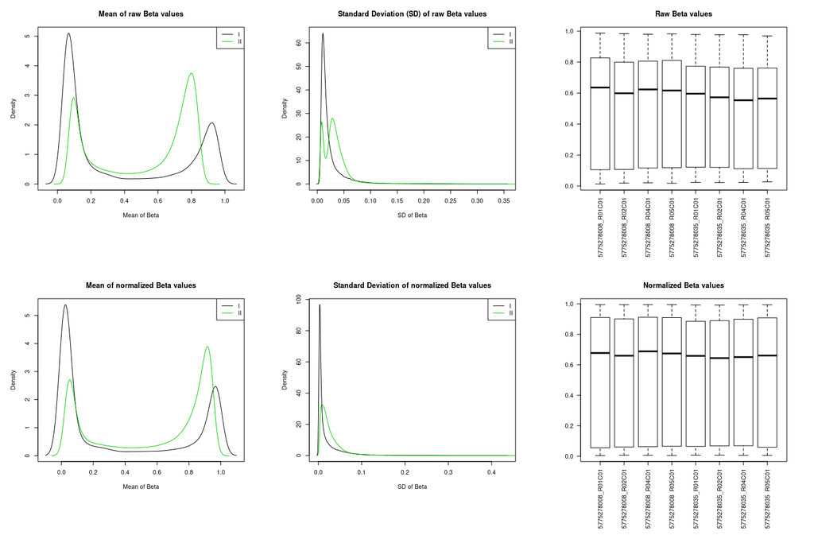

```r
legend("topright", legend=c("I", "II"), col=c("black", 259), lty=1:1)

boxplot(preprocess_Noob_beta, main="Normalized Beta values", las = 2)
```

The normalization has an immediately noticeable effect on the distribution of beta values:  
-The mean of raw Beta values shows that type II probes have lower sensitivity than type I when it comes to the detection of extreme methylation values; after normalization, the peaks are more aligned between probe types, with type II peaks closer to the extreme values.  
-The same can be said for the standard deviation; type II probes have higher SD between replicates, and the curve for raw beta values reflects this; after normalization, both curves show higher peaks but lower SD, meaning that the density for lower SDs is higher.  
-The box plot after normalization shows significantly lower variation between samples, and much more similar beta value distributions.  
Overall, the normalization procedure implemented allows to significantly reduce experimental variability both within and between samples.

### 8. Consider the normalized beta and M values and remove the probes previously defined as bad according to the detection pValue (see script Lesson5_2019)

```r
preprocess_Noob_m <- getM(preprocess_Noob_data)
preprocess_Noob_beta_clean <- preprocess_Noob_beta[!rownames(preprocess_Noob_beta) %in% bad_probes,]
preprocess_Noob_m_clean <- preprocess_Noob_m[!rownames(preprocess_Noob_beta) %in% bad_probes,]
length(bad_probes)
```

```
[1] 1905
```

```r
identical((dim(preprocess_Noob_m)[1]-dim(preprocess_Noob_m_clean)[1]), length(bad_probes))
```

```
[1] TRUE
```

```r
identical((dim(preprocess_Noob_beta)[1]-dim(preprocess_Noob_beta_clean)[1]), length(bad_probes))
```

```
[1] TRUE
```

### 9. Check beta and M matrixes generated in step 8 for homo/heteroschedasticity (see script Lesson5_2019); comment the plot. Optional: plot the lowess line.

```r
preprocess_Noob_beta_clean_mean <- apply(preprocess_Noob_beta_clean, 1, mean)
preprocess_Noob_beta_clean_sd <- apply(preprocess_Noob_beta_clean, 1, sd)
preprocess_Noob_m_clean_mean <- apply(preprocess_Noob_m_clean, 1, mean)
preprocess_Noob_m_clean_sd <- apply(preprocess_Noob_m_clean, 1, sd)
```

```r
par(mfrow=c(1,2))
smoothScatter(preprocess_Noob_beta_clean_mean, preprocess_Noob_beta_clean_sd, main="Beta values", xlab="Mean(Beta)", ylab="SD(Beta)")
lines(lowess(preprocess_Noob_beta_clean_mean, preprocess_Noob_beta_clean_sd), col="red")
```

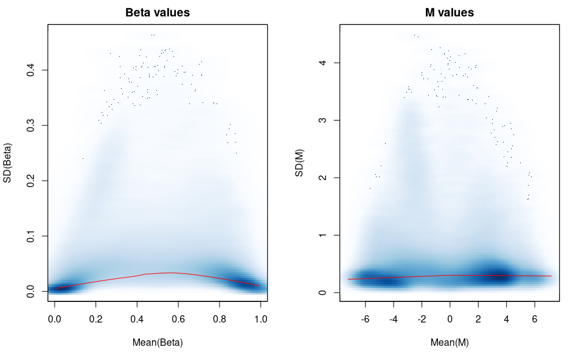

```r
smoothScatter(preprocess_Noob_m_clean_mean, preprocess_Noob_m_clean_sd, main= "M values", xlab="Mean(M)", ylab="SD(M)")
lines(lowess(preprocess_Noob_m_clean_mean, preprocess_Noob_m_clean_sd), col="red")
```

-The plot for beta values shows heteroscedasticity, with mean beta values going from 0 (absence of methylation) to 1 (complete methylation) -The plot for M values shows homoscedasticity, with mean M values not bound to the 0-1 range but going above and below. The red lines represent locally weighted scatterplot smoothing (LOWESS), which uses locally weighted polynomial regression to return a continuous line.

### 10. Perform a PCA on the beta matrix generated in step 8 to check for batch effects (see script Lesson6_2019). Comment the plot.

```r
pca_beta <- prcomp(t(preprocess_Noob_beta_clean), scale=T)
```

```r
phenotype <- read.csv("data/Input_data/Samplesheet_report.csv", sep=",")
print(summary(pca_beta))
```

```
Importance of components:
                            PC1      PC2      PC3      PC4      PC5       PC6       PC7       PC8
Standard deviation     386.1278 291.9062 256.1769 236.9907 222.7851 198.66643 195.98559 6.182e-12
Proportion of Variance   0.3083   0.1762   0.1357   0.1161   0.1026   0.08161   0.07942 0.000e+00
Cumulative Proportion    0.3083   0.4845   0.6202   0.7363   0.8390   0.92058   1.00000 1.000e+00
```

```r
str(pca_beta)
```

```
List of 5
 $ sdev    : num [1:8] 386 292 256 237 223 ...
 $ rotation: num [1:483607, 1:8] 0.000959 0.000555 0.000521 0.000234 0.00025 ...
  ..- attr(*, "dimnames")=List of 2
  .. ..$ : chr [1:483607] "cg02494853" "cg03706273" "cg04023335" "cg04462340" ...
  .. ..$ : chr [1:8] "PC1" "PC2" "PC3" "PC4" ...
 $ center  : Named num [1:483607] 0.0268 0.0291 0.3793 0.929 0.9256 ...
  ..- attr(*, "names")= chr [1:483607] "cg02494853" "cg03706273" "cg04023335" "cg04462340" ...
 $ scale   : Named num [1:483607] 0.0241 0.0183 0.289 0.0415 0.0555 ...
  ..- attr(*, "names")= chr [1:483607] "cg02494853" "cg03706273" "cg04023335" "cg04462340" ...
 $ x       : num [1:8, 1:8] -430 -101 -292 -247 622 ...
  ..- attr(*, "dimnames")=List of 2
  .. ..$ : chr [1:8] "5775278008_R01C01" "5775278008_R02C01" "5775278008_R04C01" "5775278008_R05C01" ...
  .. ..$ : chr [1:8] "PC1" "PC2" "PC3" "PC4" ...
 - attr(*, "class")= chr "prcomp"
```

```r
pca_beta$x
```

```
                        PC1         PC2        PC3         PC4        PC5        PC6         PC7           PC8
5775278008_R01C01 -429.5104  166.725162 -431.45966    4.504889  -24.49628 -200.24424 -163.555048 -1.867740e-12
5775278008_R02C01 -100.9033   87.598044  -63.67668  189.466573 -367.47901  156.72385  271.750552  1.855380e-12
5775278008_R04C01 -292.3605  106.780015  118.05738 -334.437691  239.20564  -36.14014  279.108580  1.282578e-11
5775278008_R05C01 -247.4350  -84.291727  311.44533 -221.698341 -209.52362  125.88834 -276.597444  6.343918e-12
5775278035_R01C01  621.9902  242.229130 -207.46312 -119.651727  114.31632  241.10728  -86.468341 -2.300919e-12
5775278035_R02C01  475.4532  156.463904  248.29315   85.658940  -83.88520 -350.33289    1.120401 -1.212133e-11
5775278035_R04C01  197.3388 -677.736055 -150.75509  -21.137054   32.70038  -44.70523   42.395745  2.491468e-12
5775278035_R05C01 -224.5730    2.231527  175.55869  417.294412  299.16178  107.70302  -67.754445 -2.154747e-12
```

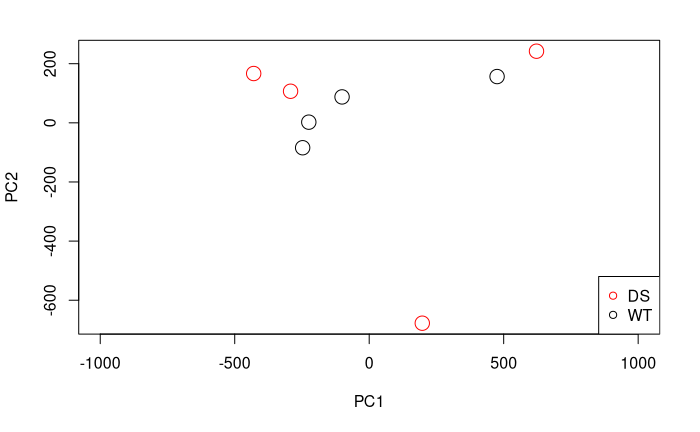

```r
plot(pca_beta$x[,1], pca_beta$x[,2], cex=2, xlab="PC1", ylab="PC2", xlim=c(-1000,1000), col=c("red","black")[as.numeric(phenotype$Group)])
#text(pca_beta$x[,1], pca_beta$x[,2], labels=rownames(pca_beta$x), cex=0.5, pos=2)
legend("bottomright", legend=levels(phenotype$Group), col=c("red","black"), pch=1)
```

### 11. Using the beta matrix generated in step 8, identify differentially methylated probes between group A and group B using the functions assigned to each student (it will take several minutes) (see script Lesson5_bis_2019). Note; it can take several minutes; if you encounter any problem you can run the differential methylated analysis only on a subset of probes (for example those on chromosome 1, 18 and 21)

```r
#anova_function <- function(x) {
#  anova_test <- aov(x ~ phenotype$Group+phenotype$Female) #ANOVA correcting for females
#  return(summary(anova_test)[[1]][[5]][1])
#}
#pval_anova <- apply(preprocess_Noob_beta_clean, 1, anova_function)
```

```r
load("pval_anova.RData")
```

### 12. Apply multiple test correction and set a significant threshold of 0.05. How many probes do you identify as differentially methylated considering nominal pValues? How many after Bonferroni correction? How many after BH correction?

```r
final_anova <- data.frame(preprocess_Noob_beta_clean, pval_anova)
final_anova <- final_anova[order(final_anova$pval_anova),]
pvals_sorted <- final_anova[,9]
pval_corrected_bh <- p.adjust(pvals_sorted, "BH")
pval_corrected_bf <- p.adjust(pvals_sorted, "bonferroni")
final_anova_corrected <- data.frame(final_anova, pval_corrected_bh, pval_corrected_bf)
```

```r
significant_probes_no_correction <- final_anova_corrected[final_anova_corrected$pval_anova<=0.05,]
dim(significant_probes_no_correction)
```

```
[1] 26615    11
```

```r
significant_probes_bh <- final_anova_corrected[final_anova_corrected$pval_corrected_bh<=0.05,]
dim(significant_probes_bh)
```

```
[1] 2482   11
```

```r
significant_probes_bf <- final_anova_corrected[final_anova_corrected$pval_corrected_bf<=0.05,]
dim(significant_probes_bf)
```

```
[1] 93 11
```

-Considering nominal pValues, 26615 probes appear to be differentially methylated. -After Benjamini & Hochberg (BH) correction, 2482 probes appear to be differentially methylated. -After Bonferroni (BF) correction, only 93 probes appear to be differentially methylated.

```r
final_anova_corrected <- data.frame(rownames(final_anova_corrected),final_anova_corrected)
```

```r
#head(final_anova_corrected)
colnames(final_anova_corrected)[1] <- "IlmnID"
```

```r
final_anova_corrected_annotated <- merge(final_anova_corrected, Illumina450Manifest_clean_pelmo, by="IlmnID")
```

```r
db <- data.frame(final_anova_corrected_annotated$CHR, final_anova_corrected_annotated$MAPINFO, final_anova_corrected_annotated$pval_anova)
db$final_anova_corrected_annotated.CHR <- factor(db$final_anova_corrected_annotated.CHR, levels=c((1:22), "X", "Y"))
```

```r
palette <- c("red","blue","green","cyan","black","gray","magenta","red","blue","green","cyan","black","gray","magenta","red","blue","green","cyan","black","gray","brown","red","blue","green")

mhtplot(db, control=mht.control(colors = palette))
```

[output not shown]

```r
title("P values of differently methylated loci")
```

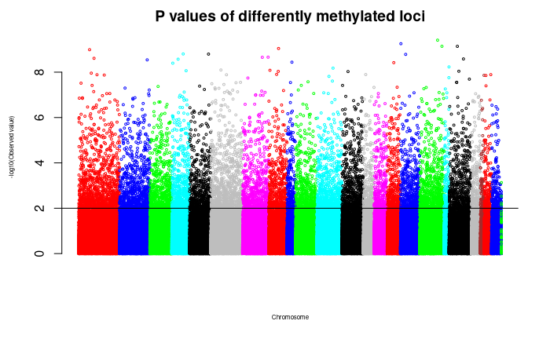

```r
axis(2,cex=0.5)
abline(a=-log10(0.01),b=0)
```

```r
head(final_anova_corrected[,1:8])
```

|  | IlmnID | X5775278008_R01C01 | X5775278008_R02C01 | X5775278008_R04C01 | X5775278008_R05C01 | X5775278035_R01C01 | X5775278035_R02C01 | X5775278035_R04C01 |
| --- | --- | --- | --- | --- | --- | --- | --- | --- |
| cg23390865 | cg23390865 | 0.05723849 | 0.05702067 | 0.4687769 | 0.4718615 | 0.05624112 | 0.4758060 | 0.05334126 |
| cg20662859 | cg20662859 | 0.06043984 | 0.05423340 | 0.4814609 | 0.4739862 | 0.06146835 | 0.4714357 | 0.06287760 |
| cg23696472 | cg23696472 | 0.02531695 | 0.01907889 | 0.6740810 | 0.6618386 | 0.02981371 | 0.6567016 | 0.02216242 |
| cg24790801 | cg24790801 | 0.01233444 | 0.01295500 | 0.5641016 | 0.5599012 | 0.01998090 | 0.5653038 | 0.01855751 |
| cg12298823 | cg12298823 | 0.01974524 | 0.01729759 | 0.5242539 | 0.5157689 | 0.02335219 | 0.5146823 | 0.01888791 |
| cg00583618 | cg00583618 | 0.01942891 | 0.01772050 | 0.5291047 | 0.5231627 | 0.02192314 | 0.5314237 | 0.01818747 |